# Lab06

Yixuan Li, UPI:yil845

20 September 2021

### * The purpose of this lab is to get experience for data exploration, linear regression, subset selection, regularisation, and prediction.

### * The Data: The data is from UCI Machine Learning Repository about the Automobile data set.

# Tasks

## Import

### 1, Import datafile “automobile-original.csv”,check data structure

```r
b<-read.csv("automobile-original.csv",stringsAsFactors = FALSE)
```

### - Processing data, 1) remove all “?” in dataframe; 2) choose engine.location of “front” only; 3)delete column engine.location; 4) change column class, col2,col21:22,col25 to integer, col18:19 to numeric; 5) write file“automobile.csv” without indexing rownames.

```r
btemp<- b[b$normalized.losses!="?" & b$num.of.doors!="?" & b$bore!="?" & b$stroke!="?" & b$horsepower!="?" & b$peak.rpm!="?" & b$engine.location =="front",]
btemp<- btemp[,-9]
btemp[,c(2,21:22,25)]<- sapply(btemp[,c(2,21:22,25)],as.integer)
btemp[,c(18:19)]<-sapply(btemp[,c(18,19)],as.numeric)
write.csv(btemp,"automobile.csv",row.names = FALSE)
```

### - Import data “automobile.csv”, and compare it with data imported from “automobile-subset.csv”.

```r
b2<- read.csv("automobile.csv",stringsAsFactors = TRUE)
dim(b2)
```

```
## [1] 159  25
```

```r
b1<-read.csv("automobile-subset.csv",stringsAsFactors = TRUE)
all(b1 == b2)
```

```
## [1] TRUE
```

# Explore

## 2, Write R code to answer the following questions:

### - What is the mean price of all vehicles?

```r
mean(b2$price)
```

```
## [1] 11445.73
```

### - How many vehicles have 4 doors ?

```r
nrow(b2[b2$num.of.doors=="four",])
```

```
## [1] 95
```

### - What are the different engine types among the observations?

```r
unique(b2$engine.type)
```

```
## [1] ohc  l    dohc ohcv ohcf
## Levels: dohc l ohc ohcf ohcv
```

### - How many vehicles have a price higher than $20000?

```r
nrow(b2[b2$price > 20000,])
```

```
## [1] 13
```

### - What is the mean price for “4wd”?

```r
m<-b2[b2$drive.wheels=="4wd",]
mean(m$price)
```

```
## [1] 10241
```

## 3, Produce pairwise scatterplots between variables normalized.losses, wheel.base, peak.rpm and price. The plot shows a linear dependence between price and wheel.base. However, for normalized.losses and peak.rpm, we hardly see any linear correspondence.

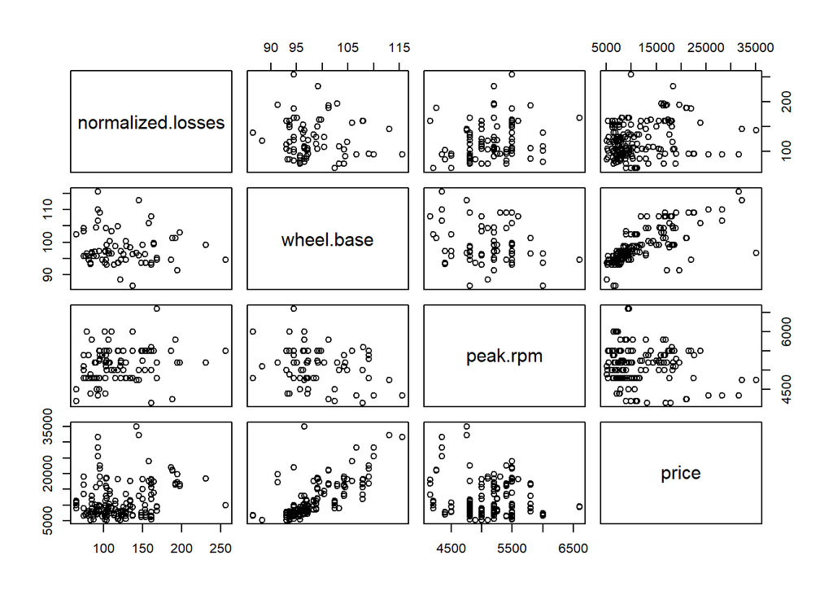

```r
bp<-b2[,c(2,9,22,25)]
pairs(bp)
```

# Linear regression

## 4,Produce the full linear regression model with all variables included.

### The outcome shows the validness of linear regression model based on ordinary least square (OLS) estimation. It shows fomula, residuals calculated, coefficiants which includes estimated coefficients, standard Error, t values of t test and p value of t test. The stars shows how significant the p values are, * means significant with 0.05< p < 0.01; ** means middle significant with 0.01 < p < 0.001; *** means highly significiant with 0 < p < 0.001; “.” means p value between 0.05 and 0.1. Multiple R^2 is the correlation coefficient of overall fitting (>0.97) and adjusted R^2, indicating a very good linear fitting. We notice “NA” are generated due to poor linear relationships of the relevant parameters. To improve our fitting, we need to remove those parameters.

```r
r<-lm(price~.-symboling, data=b2)
summary(r)
```

```
##
## Call:
## lm(formula = price ~ . - symboling, data = b2)
##
## Residuals:
##     Min      1Q  Median      3Q     Max
## -2949.1  -587.9     0.0   649.4  2260.2
##
## Coefficients: (3 not defined because of singularities)
##                         Estimate Std. Error t value Pr(>|t|)
## (Intercept)            2.305e+04  1.545e+04   1.492 0.138508
## normalized.losses      5.561e+00  6.186e+00   0.899 0.370596
## makebmw                3.725e+02  1.697e+03   0.220 0.826622
## makechevrolet         -4.733e+03  1.773e+03  -2.669 0.008779 **
## makedodge             -6.198e+03  1.532e+03  -4.046 9.79e-05 ***
## makehonda             -1.574e+03  1.691e+03  -0.931 0.354043
## makejaguar             2.442e+03  2.866e+03   0.852 0.396016
## makemazda             -4.053e+03  1.511e+03  -2.683 0.008442 **
## makemercedes-benz      2.560e+03  1.518e+03   1.686 0.094658 .
## makemitsubishi        -6.321e+03  1.542e+03  -4.098 8.09e-05 ***
## makenissan            -3.680e+03  1.410e+03  -2.611 0.010324 *
## makepeugot            -5.136e+03  4.700e+03  -1.093 0.276957
## makeplymouth          -6.015e+03  1.548e+03  -3.884 0.000177 ***
## makeporsche            4.840e+03  2.043e+03   2.368 0.019642 *
## makesaab              -4.050e+02  1.544e+03  -0.262 0.793625
## makesubaru            -7.306e+03  2.241e+03  -3.260 0.001489 **
## maketoyota            -5.859e+03  1.526e+03  -3.841 0.000207 ***
## makevolkswagen        -4.297e+03  1.349e+03  -3.185 0.001892 **
## makevolvo             -2.855e+03  1.698e+03  -1.682 0.095536 .
## fuel.typegas          -1.066e+04  5.079e+03  -2.099 0.038125 *
## aspirationturbo        2.169e+03  5.793e+02   3.743 0.000293 ***
## num.of.doorstwo       -8.410e+02  3.563e+02  -2.360 0.020057 *
## body.stylehardtop     -5.625e+03  1.367e+03  -4.116 7.56e-05 ***
## body.stylehatchback   -5.732e+03  1.328e+03  -4.316 3.53e-05 ***
## body.stylesedan       -5.698e+03  1.377e+03  -4.137 6.98e-05 ***
## body.stylewagon       -5.644e+03  1.401e+03  -4.028 0.000105 ***
## drive.wheelsfwd       -2.760e+01  6.427e+02  -0.043 0.965823
## drive.wheelsrwd        1.977e+03  9.507e+02   2.079 0.039967 *
## wheel.base             3.188e+02  8.129e+01   3.922 0.000155 ***
## length                -7.656e+01  3.781e+01  -2.025 0.045325 *
```

[output cut: 15 more lines]

```
## fuel.systemmpfi        2.600e+03  1.072e+03   2.424 0.016997 *
## fuel.systemspdi        1.081e+03  1.286e+03   0.840 0.402560
## bore                  -8.830e+02  1.420e+03  -0.622 0.535226
## stroke                -5.652e+02  9.422e+02  -0.600 0.549856
## compression.ratio     -7.012e+02  3.791e+02  -1.850 0.067084 .
## horsepower            -2.017e+01  1.899e+01  -1.062 0.290628
## peak.rpm              -5.391e-01  5.600e-01  -0.963 0.337901
## city.mpg              -1.561e+02  1.016e+02  -1.535 0.127596
## highway.mpg            1.281e+02  8.776e+01   1.460 0.147255
## ---
## Signif. codes:  0 '***' 0.001 '**' 0.01 '*' 0.05 '.' 0.1 ' ' 1
##
## Residual standard error: 1159 on 108 degrees of freedom
## Multiple R-squared:  0.9734, Adjusted R-squared:  0.9611
## F-statistic: 79.05 on 50 and 108 DF,  p-value: < 2.2e-16
```

```r
lr<-lm(price~.-symboling -normalized.losses -engine.type -num.of.cylinders -fuel.system, data=b2)
summary(lr) ## comment on outcome
```

```
##
## Call:
## lm(formula = price ~ . - symboling - normalized.losses - engine.type -
##     num.of.cylinders - fuel.system, data = b2)
##
## Residuals:
##      Min       1Q   Median       3Q      Max
## -2862.24  -713.33   -25.37   771.77  3019.25
##
## Coefficients:
##                       Estimate Std. Error t value Pr(>|t|)
## (Intercept)         13368.2796 14319.5060   0.934 0.352415
## makebmw              1302.9182  1339.3589   0.973 0.332630
## makechevrolet       -4437.0773  1325.1646  -3.348 0.001089 **
## makedodge           -6196.0728  1044.6147  -5.931 3.02e-08 ***
## makehonda           -4187.1955   945.7129  -4.428 2.13e-05 ***
## makejaguar           2699.1243  2068.1020   1.305 0.194369
## makemazda           -3832.8735   919.7958  -4.167 5.88e-05 ***
## makemercedes-benz    2950.4883  1277.5168   2.310 0.022637 *
## makemitsubishi      -6886.4754   984.0162  -6.998 1.64e-10 ***
## makenissan          -3848.5948   922.6569  -4.171 5.79e-05 ***
## makepeugot          -6397.2324  1310.1481  -4.883 3.29e-06 ***
## makeplymouth        -6302.8597  1071.8056  -5.881 3.83e-08 ***
## makeporsche          3888.8119  1716.5909   2.265 0.025295 *
## makesaab             -412.3341  1222.0152  -0.337 0.736394
## makesubaru          -4997.9941  1408.4027  -3.549 0.000555 ***
## maketoyota          -5478.0484   964.1106  -5.682 9.63e-08 ***
## makevolkswagen      -4148.5040   912.1549  -4.548 1.31e-05 ***
## makevolvo           -2797.8073  1123.0805  -2.491 0.014110 *
## fuel.typegas        -2859.1271  4212.7345  -0.679 0.498654
## aspirationturbo      1658.3804   584.1557   2.839 0.005324 **
## num.of.doorstwo      -569.8647   356.0451  -1.601 0.112130
## body.stylehardtop   -6511.8512  1177.1217  -5.532 1.91e-07 ***
## body.stylehatchback -6034.1063  1078.1612  -5.597 1.42e-07 ***
## body.stylesedan     -5772.8527  1149.8562  -5.020 1.83e-06 ***
## body.stylewagon     -5832.2150  1209.3778  -4.822 4.24e-06 ***
## drive.wheelsfwd      -264.5284   669.1118  -0.395 0.693298
## drive.wheelsrwd      1409.0973   929.4784   1.516 0.132169
## wheel.base            283.2453    75.8379   3.735 0.000290 ***
## length                -78.0576    36.3489  -2.147 0.033785 *
## width                 205.6299   189.9011   1.083 0.281075
## height               -365.4615   110.1231  -3.319 0.001201 **
## curb.weight             5.2188     1.2756   4.091 7.85e-05 ***
## engine.size             9.9592    16.9817   0.586 0.558671
## bore                -2286.1326   940.0653  -2.432 0.016510 *
## stroke               -628.0364   845.7784  -0.743 0.459215
## compression.ratio    -259.5834   317.9962  -0.816 0.415954
## horsepower             10.1422    15.3965   0.659 0.511340
## peak.rpm               -0.1438     0.4844  -0.297 0.767159
## city.mpg              -72.3725   101.5658  -0.713 0.477509
## highway.mpg            62.0067    89.0011   0.697 0.487352
## ---
## Signif. codes:  0 '***' 0.001 '**' 0.01 '*' 0.05 '.' 0.1 ' ' 1
##
## Residual standard error: 1230 on 119 degrees of freedom
## Multiple R-squared:  0.967,  Adjusted R-squared:  0.9562
## F-statistic: 89.47 on 39 and 119 DF,  p-value: < 2.2e-16
```

```r
# count how many P values show significance, in total 24.
sum(summary(lr)$coefficients[,4]<0.05)
```

```
## [1] 24
```

```r
MSE <- function(o, p) mean((o - p)^2)
MSE(predict(lr,b2),b2$price)
```

```
## [1] 1132209
```

```r
##RMSE
sqrt(MSE(predict(lr,b2),b2$price))
```

```
## [1] 1064.053
```

# subset selection

## 7,produce a subset linear regression model, using the backward selection and the AIC.

```r
rl.bac<- regsubsets(price~.-symboling -normalized.losses -engine.type -num.of.cylinders -fuel.system, data=b2, nvmax=50, method="backward")
rl.b=summary(rl.bac)
```

## calculate AIC based on formula: BIC(k)-log(n)*k+2*k

```r
# count number of fitting parameters
k<-1:(ncol(rl.b$which)-1)
aic<-rl.b$bic-log(159)*k+2*k
aic
```

```
##  [1] -247.7153 -257.4944 -268.2075 -271.0805 -278.4920 -286.5273 -292.8073
##  [8] -298.9789 -307.4123 -312.6586 -321.7452 -340.5615 -351.6461 -366.2102
## [15] -374.7714 -401.7675 -409.4260 -411.8684 -413.0535 -426.6856 -445.2621
## [22] -455.8051 -457.2931 -461.9682 -464.8567 -470.9015 -472.8157 -474.7675
## [29] -474.1080 -472.7594 -472.2000 -471.2258 -470.0883 -468.1549 -466.7159
## [36] -464.9864 -463.2177 -461.3062 -459.4239
```

## 8,Apply the AIC-selected model to the data and compute the resulting MSE.

```r
# model matrix
b2.matrix = model.matrix(price~. -symboling -normalized.losses -engine.type -num.of.cylinders -fuel.system, data=b2)

j<-which.min(aic)
beta=coef(rl.bac,j)
b2j.matrix=b2.matrix[,names(beta)]
yhat = drop(b2j.matrix %*% beta)
resid = b2$price - yhat
## MSE
mean(resid^2)
```

```
## [1] 1180614
```

```r
##RMSE
sqrt(mean(resid^2))
```

```
## [1] 1086.561
```

## 9, The following codes create a plot that shows the predictions of min(AIC)-selected model against the response variable (price), using different colors for different levels of drive.wheels.

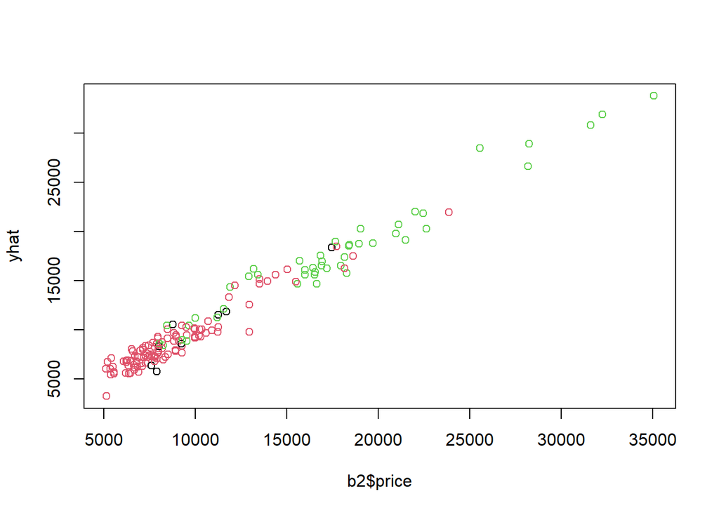

```r
# the majority of red spot - forward-wheels-drive cars (fwd) dominated at lower price range,whereas rear-wheels-drive (rwd) cars at higher price range.
plot(b2$price,yhat,col=as.numeric(factor(b2$drive.wheels)),)
```

```r
#levels(b2$drive.wheels); 4wd(black),fwd(red),rwd(green)
```

## 10,For the full data selected, compute the Lasso model.

```r
x<-b2.matrix[,-1] # remove intercept
y<-b2$price
lr.lasso<-glmnet(x,y,alpha=1)
#lr.lasso
```

## 11, these codes Create a coefficient profile plot of the coefficient price that varies with the value of log(λ).

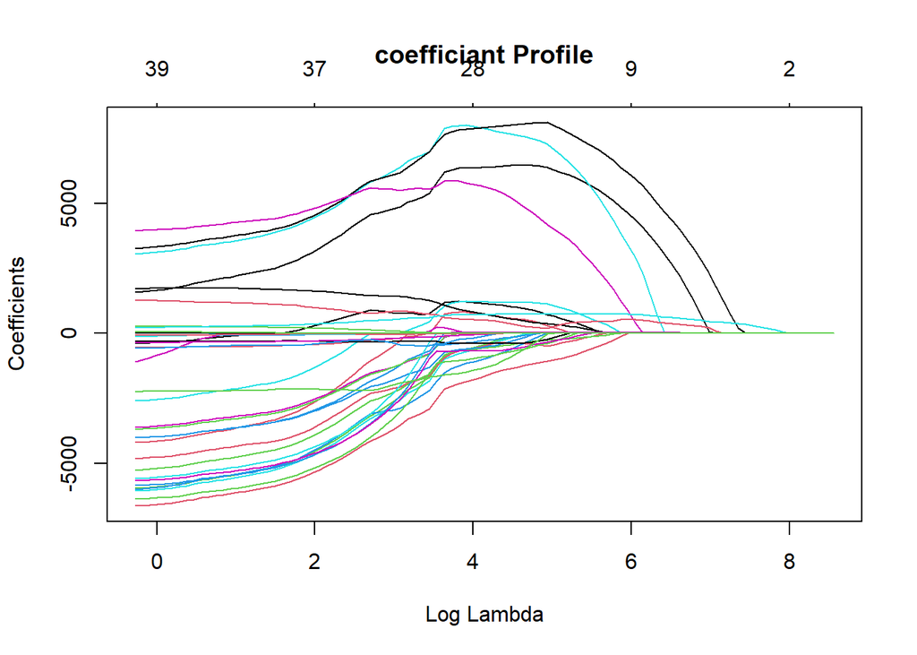

```r
plot(lr.lasso,xvar="lambda" ,main="coefficiant Profile")
```